# Prepare poll data for model estimation

## Libraries and functions

```r
library(ggplot2)
library(dplyr)
names_functions = list.files(here::here("functions"))
for (f in names_functions)
    source(here::here("functions", f))
rm(f, names_functions)
```

## Load polls for 2024, pollsters and dates

```r
rawdat <- read.csv(
    here::here("data", "dataland_polls_2024_scenarios.csv"), stringsAsFactors = FALSE)
dat <- rawdat
```

Load list of pollsters

```r
pollsters <- load_pollsters()
```

Load the dates of the election campaign -> start = earliest recorded poll

```r
dates_campaign <- load_dates_election_campaign()
```

## Transform and explore data

### Polls

Add column indicating the *type of poll*: national, regional or state

```r
states_regions <- load_dataland_states_regions()
dat$type_of_poll <- determine_type_of_poll(dat$geography, states_regions)
```

Rescale vote shares to account for undecided voters -> party shares need to sum to 1!

```r
dat %>%
    mutate(sum_shares_parties = cc_poll_share +
                                    dgm_poll_share +
                                        pdal_poll_share +
                                            ssp_poll_share,
           cc_poll_share      = cc_poll_share / sum_shares_parties,
           dgm_poll_share     = dgm_poll_share / sum_shares_parties,
           pdal_poll_share    = pdal_poll_share / sum_shares_parties,
           ssp_poll_share     = ssp_poll_share / sum_shares_parties) %>%
    select(-sum_shares_parties) -> dat
```

Check that shares (approximately) sum to 1:

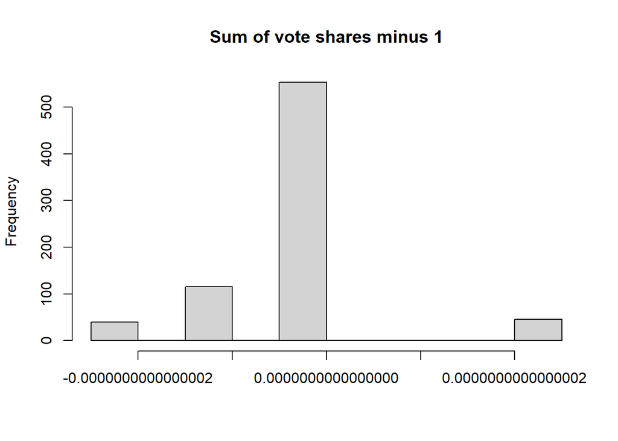

Simplify names of party vote shares

```r
dat <- rename(dat,
    cc_share      = cc_poll_share,
    dgm_share     = dgm_poll_share,
    pdal_share    = pdal_poll_share,
    ssp_share     = ssp_poll_share)
```

### Date

Since results reflect the voting intentions when the poll was *conducted*, set `date_conducted` to `date`. In any case, the publication lags of polls do not vary much and are at most two days so it probably does not make much of a difference which of the two variables - `date_conducted` or `date_published` is chosen as the “date” of a poll.

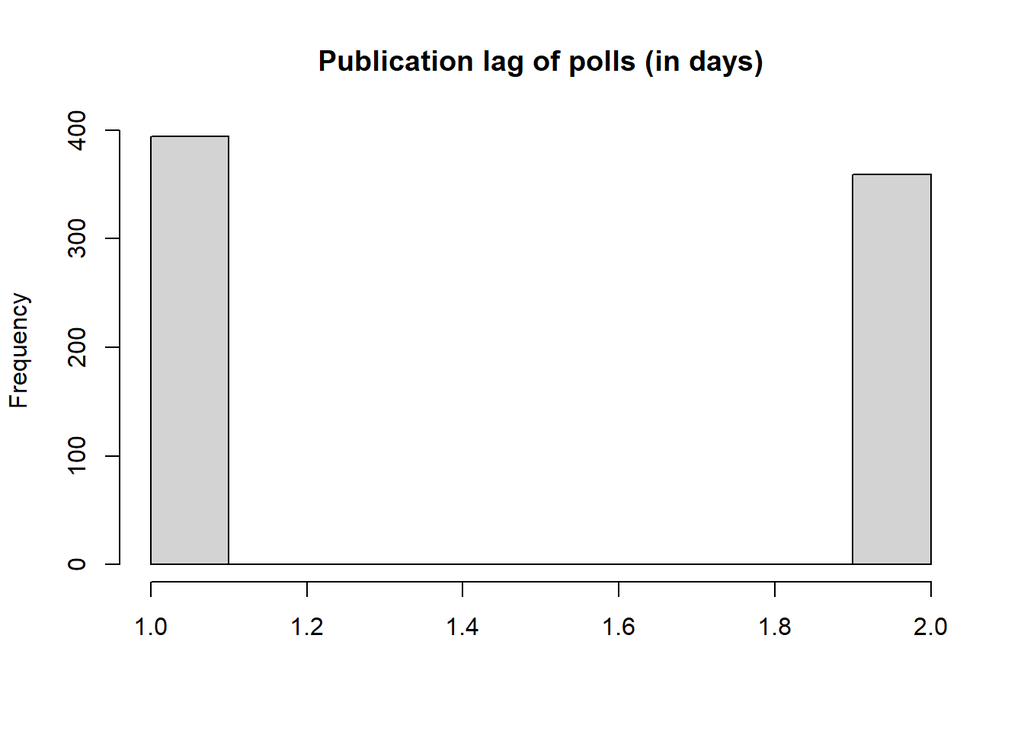

```r
publication_lag <- as.Date(dat$date_published) -
                    as.Date(dat$date_conducted)
hist(
    as.numeric(publication_lag),
    xlab = "",
    main = "Publication lag of polls (in days)"
)
```

```r
dat %>%
    mutate(
        date = as.Date(date_conducted)) %>%
    select(
        -c("date_published", "date_conducted")
     ) -> dat
```

### Plots

#### By month

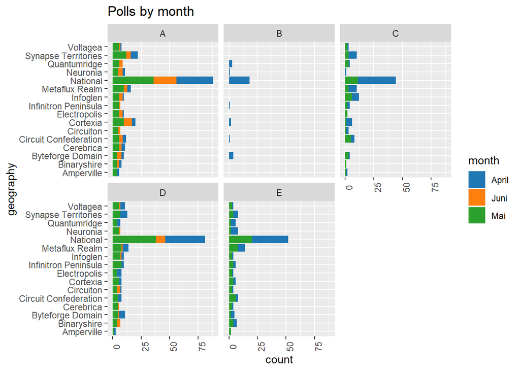

#### By type

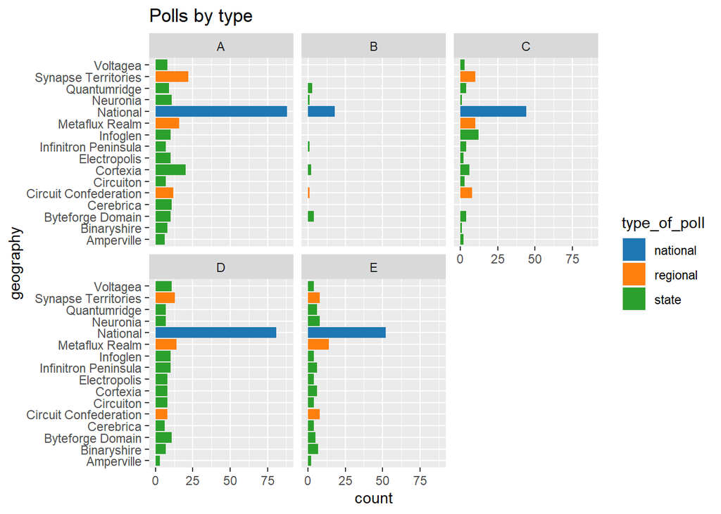

#### By sponsor

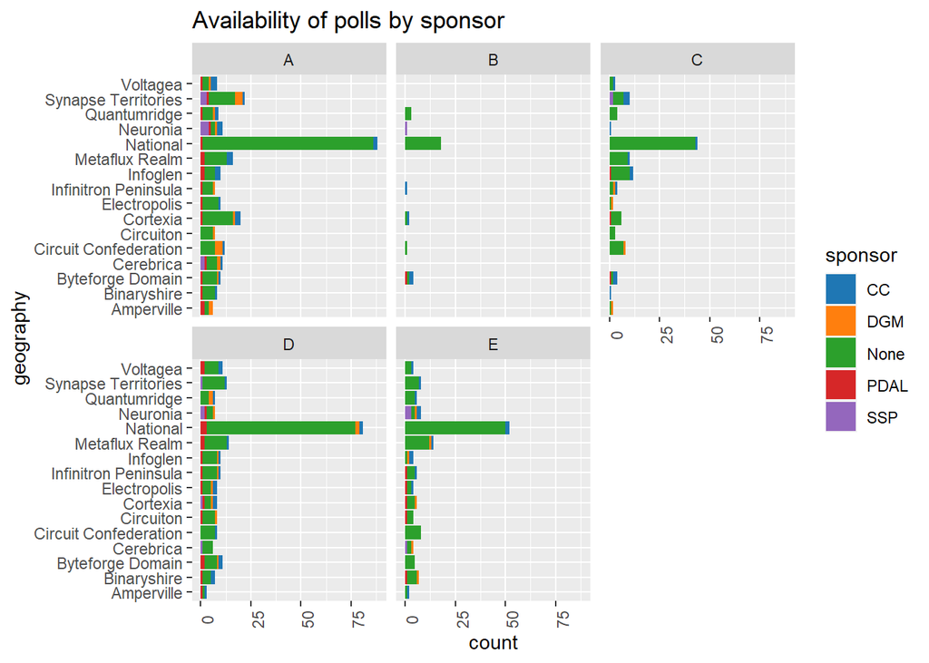

#### By polling house

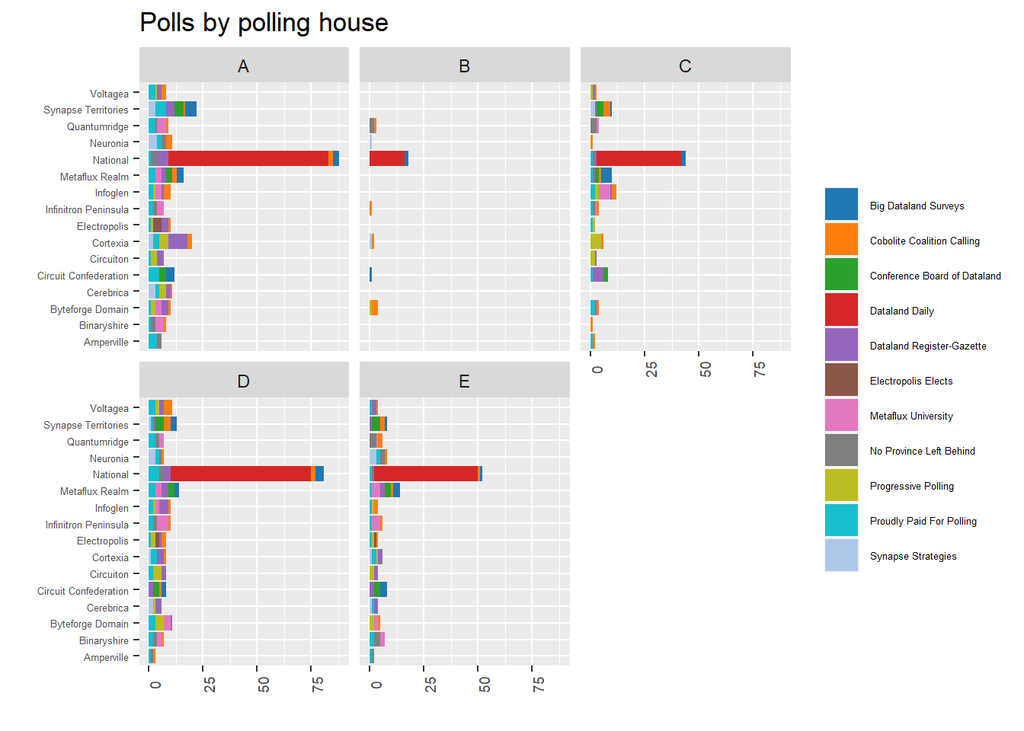

```r
dat %>%
    ggplot(
        aes(x = geography,
            fill = pollster)) +
    geom_bar() +
    ggsci::scale_fill_d3("category20") +
    facet_wrap(~ scenario) +
    labs(
        x = "",
        y = "",
        title = "Polls by polling house") +
    theme(
        axis.text.x = element_text(angle = 90, size = 7),
        axis.text.y = element_text(size = 5),
        legend.text = element_text(size = 5),
        legend.title = element_blank()) +
    coord_flip()
```

```r
ggsave(file = here::here("data", "polls_by_house.png"))
```

#### By polling mode

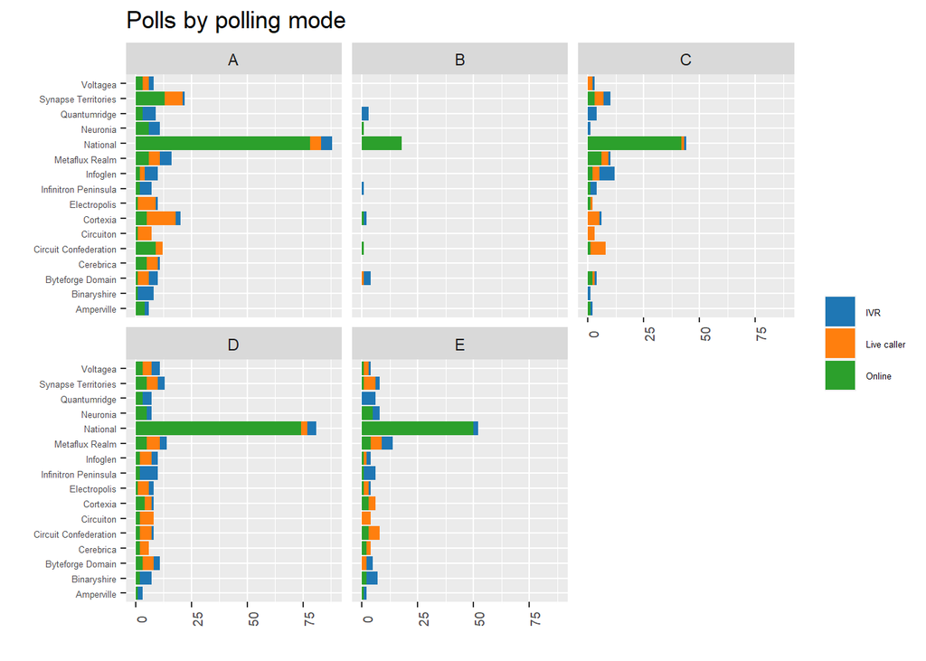

```r
dat %>%
    ggplot(
        aes(x = geography,
            fill = mode)) +
    geom_bar() +
    ggsci::scale_fill_d3("category20") +
    facet_wrap(~ scenario) +
    labs(
        x = "",
        y = "",
        title = "Polls by polling mode") +
    theme(
        axis.text.x = element_text(angle = 90, size = 7),
        axis.text.y = element_text(size = 5),
        legend.text = element_text(size = 5),
        legend.title = element_blank()) +
    coord_flip()
```

```r
ggsave(file = here::here("data", "polls_by_mode.png"))
```

#### By population surveyed

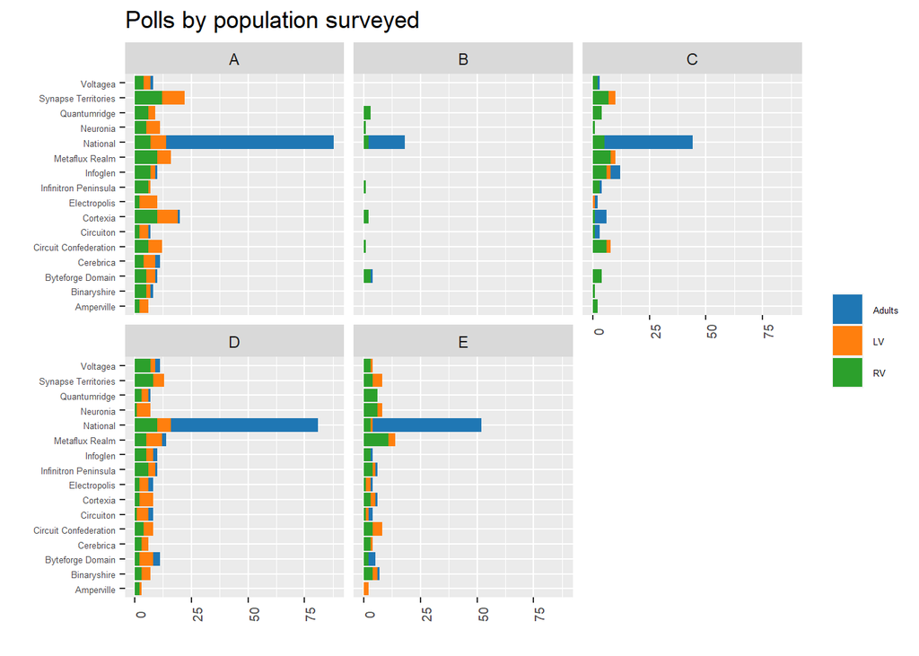

```r
dat %>%
    ggplot(
        aes(x = geography,
            fill = population_surveyed)) +
    geom_bar() +
    ggsci::scale_fill_d3("category20") +
    facet_wrap(~ scenario) +
    labs(
        x = "",
        y = "",
        title = "Polls by population surveyed") +
    theme(
        axis.text.x = element_text(angle = 90, size = 7),
        axis.text.y = element_text(size = 5),
        legend.text = element_text(size = 5),
        legend.title = element_blank()) +
    coord_flip()
```

```r
ggsave(file = here::here("data", "polls_by_population.png"))
```

## Convert polls to a Stan-friendly list

```r
keep_cols_stan <- c("scenario", "type_of_poll", "date",
                    "pollster", "geography", "sample_size",
                    "cc_share", "dgm_share",
                    "pdal_share", "ssp_share")
dat <- dat[, keep_cols_stan]
```

Loop over scenarios

```r
scenarios <- load_scenarios()
polls <- list() # initialize empty list
for (scenario in scenarios){

    polls[[scenario]] <- list()


    # state polls----

    dat %>%
        filter(scenario == .env$scenario,
               type_of_poll == "state") %>%
        arrange(date) -> df_polls_state

    # convert vote shares to votes
    df_polls_state %>%
        mutate( cc_n      = round(cc_share * sample_size, digits = 0),
                dgm_n     = round(dgm_share * sample_size, digits = 0),
                pdal_n    = round(pdal_share * sample_size, digits = 0),
                ssp_n     = round(ssp_share * sample_size, digits = 0)) -> df_polls_state

    # store data in list
    polls[[scenario]][["n_responses"]]   <- df_polls_state$sample_size
    polls[[scenario]][["day_poll"]]      <- sapply(df_polls_state$date,
                                                function(x){ which(dates_campaign == x)})
    polls[[scenario]][["house_poll"]]    <- sapply(df_polls_state$pollster,
                                                function(x){which(pollsters == x)})
    polls[[scenario]][["state_poll"]]    <- sapply(df_polls_state$geography,
                                                function(x){which(states_regions$state == x)})
    polls[[scenario]][["y"]]             <- t(as.matrix(df_polls_state[, c("cc_n", "dgm_n", "pdal_n", "ssp_n")]))

    # regional polls ----
    dat %>%
        filter(scenario == .env$scenario,
               type_of_poll == "regional") %>%
        arrange(date) -> df_polls_region

    # convert vote shares to votes
    df_polls_region %>%
        mutate( cc_n      = round(cc_share * sample_size, digits = 0),
                dgm_n     = round(dgm_share * sample_size, digits = 0),
                pdal_n    = round(pdal_share * sample_size, digits = 0),
                ssp_n     = round(ssp_share * sample_size, digits = 0)) -> df_polls_region

    polls[[scenario]][["n_responses_reg"]]   <- df_polls_region$sample_size
    polls[[scenario]][["day_poll_reg"]]      <- sapply(df_polls_region$date,
                                                        function(x){ which(dates_campaign == x)})
    polls[[scenario]][["house_poll_reg"]]    <- sapply(df_polls_region$pollster,
                                                        function(x){which(pollsters == x)})
    polls[[scenario]][["region_poll"]]       <- sapply(df_polls_region$geography,
                                                        function(x){which(unique(states_regions$region) == x)})
    polls[[scenario]][["y_reg"]]             <- t(as.matrix(df_polls_region[, c("cc_n", "dgm_n", "pdal_n", "ssp_n")]))

    # national polls ----
    dat %>%
        filter(scenario == .env$scenario,
               type_of_poll == "national") %>%
        arrange(date) -> df_polls_national

    # convert vote shares to votes
    df_polls_national %>%
        mutate( cc_n      = round(cc_share * sample_size, digits = 0),
                dgm_n     = round(dgm_share * sample_size, digits = 0),
                pdal_n    = round(pdal_share * sample_size, digits = 0),
                ssp_n     = round(ssp_share * sample_size, digits = 0)) -> df_polls_national

    polls[[scenario]][["n_responses_nat"]]   <- df_polls_national$sample_size
    polls[[scenario]][["day_poll_nat"]]      <- sapply(df_polls_national$date,
                                                    function(x){ which(dates_campaign == x)})
    polls[[scenario]][["house_poll_nat"]]    <- sapply(df_polls_national$pollster,
                                                    function(x){which(pollsters == x)})
    polls[[scenario]][["y_nat"]]             <- t(as.matrix(df_polls_national[, c("cc_n", "dgm_n", "pdal_n", "ssp_n")]))

    # merge and convert polls to long format
    do.call("rbind",
            list(df_polls_state, df_polls_region, df_polls_national)) %>%
    rename(CC = cc_n,
           DGM = dgm_n,
           PDAL = pdal_n,
           SSP = ssp_n) %>%
    select(-ends_with("_share")) %>%
    tidyr::pivot_longer(cols = -c("scenario",
                                  "date",
                                  "geography",
                                  "sample_size",
                                  "pollster",
                                  "type_of_poll"),
                        names_to = "party",
                        values_to = "value") -> df_polls

    # export polls to csv
    write.csv(df_polls,
              file = here::here("data", paste0("df_polls_", scenario, ".csv")),
              row.names = FALSE)

    # Clean up ----
    rm(df_polls_state, df_polls_region, df_polls_national, df_polls)
}

# Export ----
saveRDS(polls, file = here::here("data", paste0("polls.Rds")))
rm(polls)
```

## Plot polls

Define auxiliary functions to generate plots for a given scenario

```r
plot_state_polls <- function(scen) {
    df_polls <- read.csv(here::here("data", paste0("df_polls_", scen, ".csv")), stringsAsFactors = FALSE)
    df_polls$date <- as.Date(df_polls$date)

    df_polls %>%
        filter(type_of_poll == "state") %>%
        # set zero values for SSP in non-Synapse Territories to NA for better visibility
        mutate(value = ifelse(value == 0,
                                NA,
                                value)) %>%
        ggplot(aes(x = date, y = value/sample_size, color = party)) +
        ggsci::scale_color_jco() +
        scale_x_date(date_labels = "%b-%d") +
        geom_point() +
        facet_wrap(~geography, nrow = 4) +
        labs(title = paste0(scen, ": state polls")) +
        theme(legend.position="top") -> plt_state

    plt_state
}
```

```r
plot_regnat_polls <- function(scen) {
    df_polls <- read.csv(here::here("data", paste0("df_polls_", scen, ".csv")), stringsAsFactors = FALSE)

    df_polls$date <- as.Date(df_polls$date)

    df_polls %>%
        filter(type_of_poll != "state") %>%
        # set zero values for SSP in non-Synapse Territories to NA for better visibility
        mutate(value = ifelse(value == 0,
                                NA,
                                value)) %>%
        ggplot(aes(x = date, y = value/sample_size, color = party)) +
        ggsci::scale_color_jco() +
        geom_point() +
        facet_wrap(~geography, nrow = 2) +
        labs(title = paste0(scen, ": regional and national polls")) +
        theme(legend.position="top") -> plt_regnat
    plt_regnat
}
```

### Scenarios

**A**

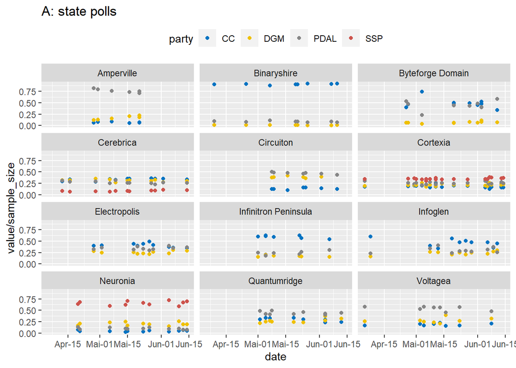

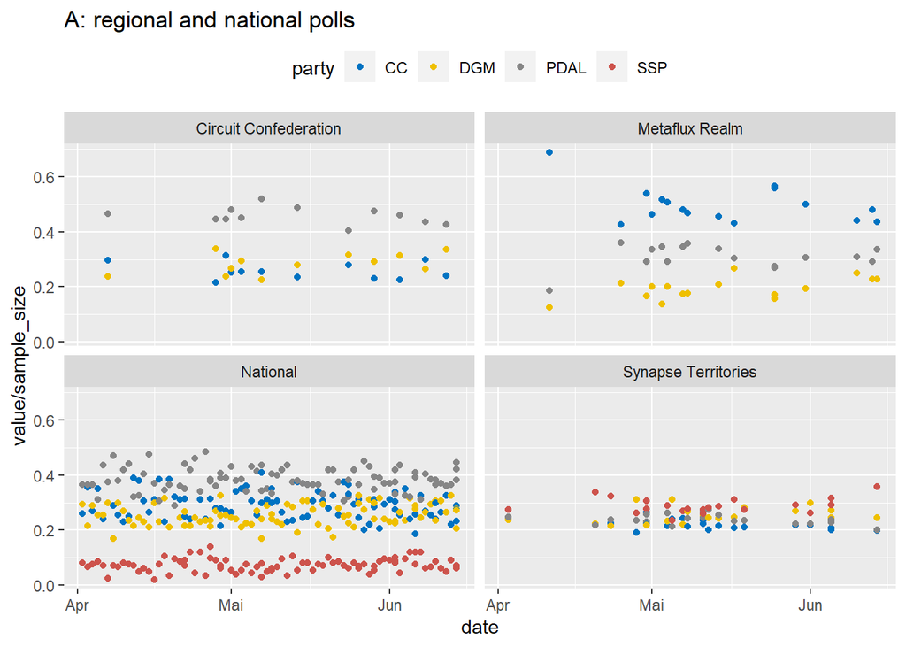

**B**

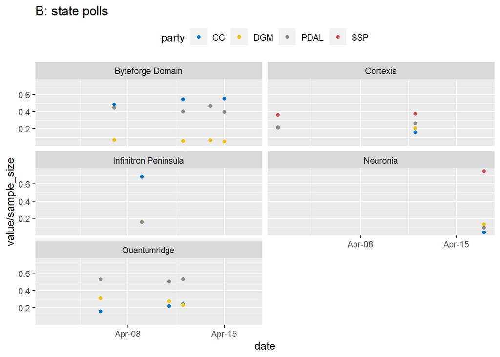

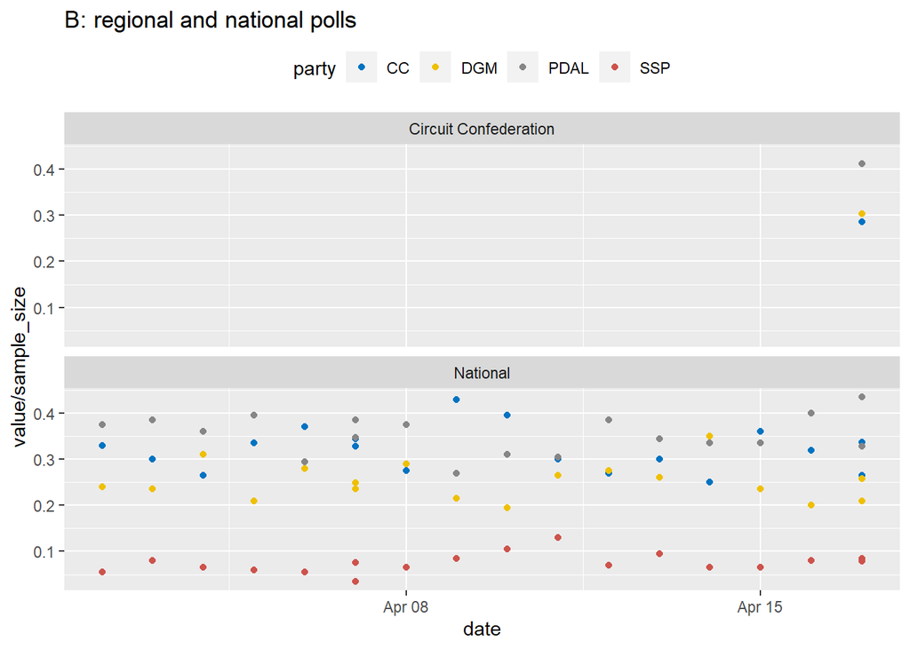

**C**

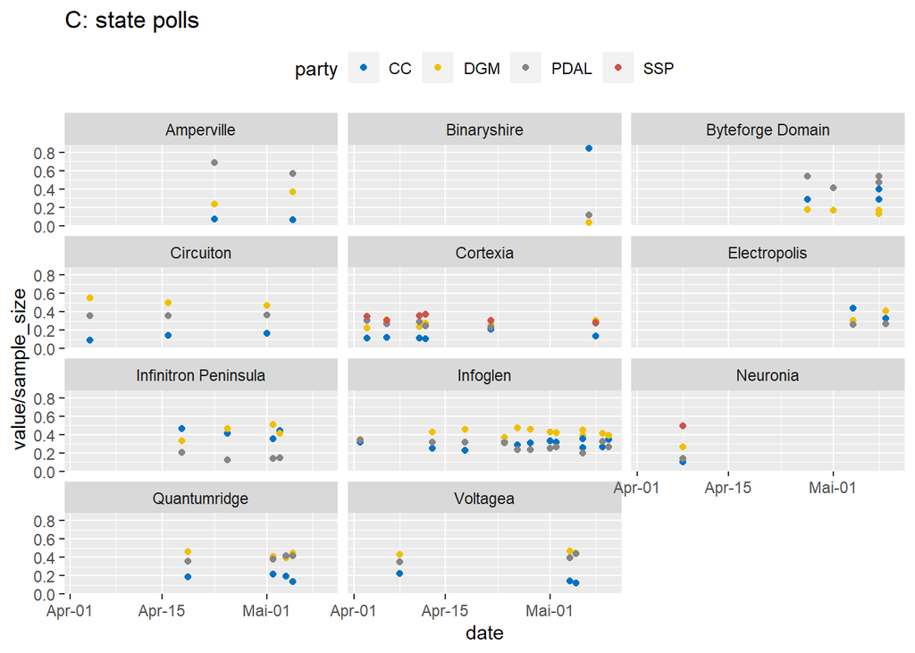

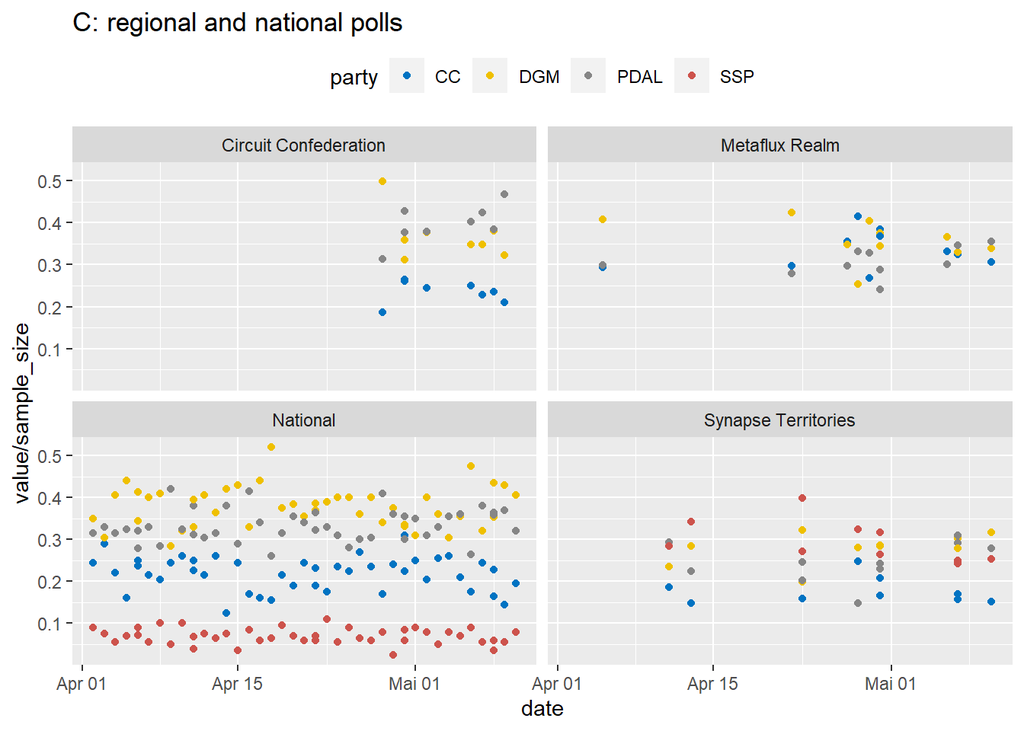

**D**

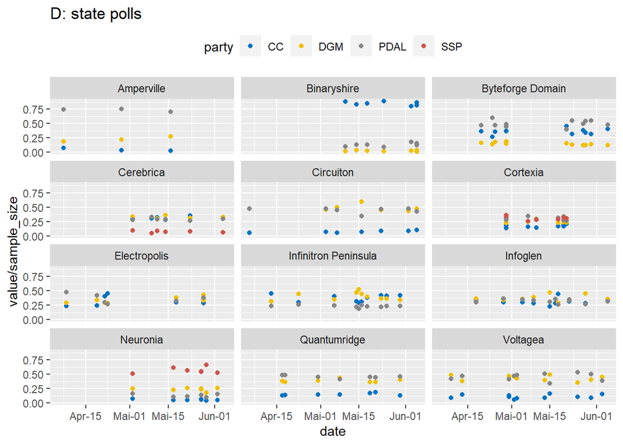

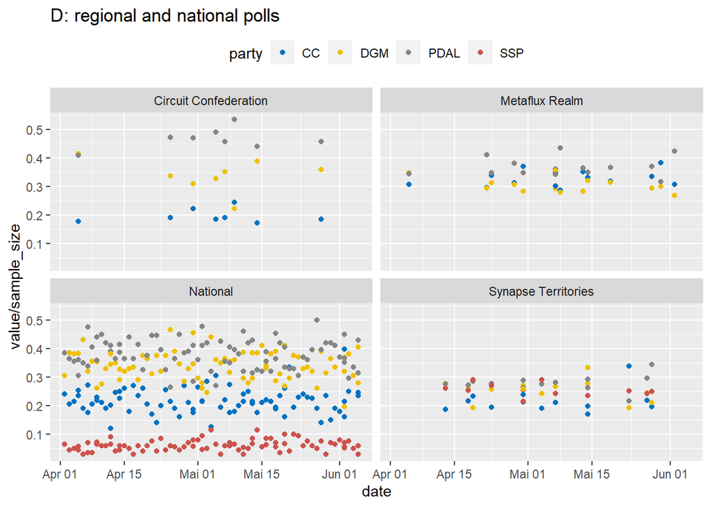

**E**

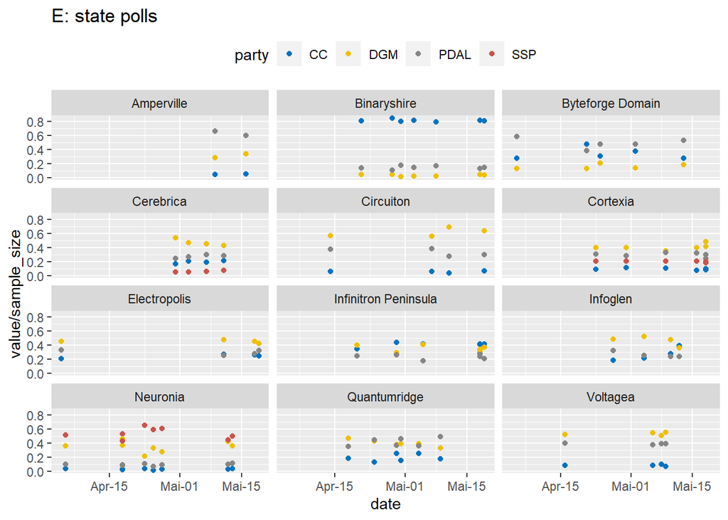

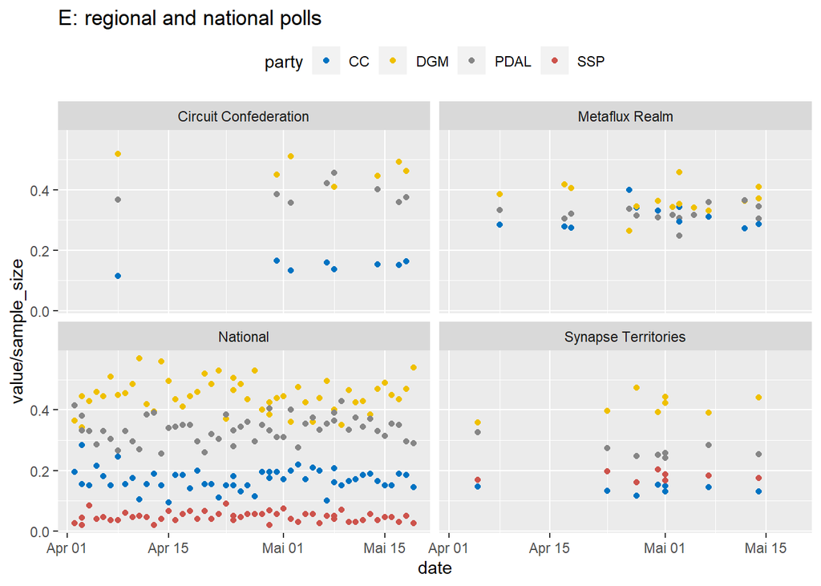

## Compare differences between sum of votes and total number of responses

As a consequence of rounding the product of vote share and number of poll respondents to an integer, the sum of votes for the parties may not exactly match the total number of respondents in the poll.

How large are these discrepancies?

```r
polls <- readRDS(here::here("data", "polls.Rds"))
df_diff <- data.frame()
for (s in scenarios){
    for (i in c("", "_reg", "_nat")){
        y <- polls[[s]][[paste0("y", i)]]
        n_responses <- polls[[s]][[paste0("n_responses", i)]]
        diff_response <- apply(y, c(2), sum) - n_responses
        df_diff <- rbind(df_diff, data.frame(scenario = s,
                                            type = ifelse(i == "","state", substr(i, 2, nchar(i))),
                                            n_diff = sum(diff_response != 0),
                                            n_polls = length(diff_response),
                                            ratio_n_diff = sum(diff_response != 0)/length(diff_response),
                                            max_abs_diff = max(abs(diff_response)),
                                            min_N = min(n_responses),
                                            ratio_maxdiff_minN = max(abs(diff_response))/min(n_responses)
                                        )
                        )
    }
}

df_diff %>%
    arrange(desc(ratio_maxdiff_minN))
```

```
   scenario  type n_diff n_polls ratio_n_diff max_abs_diff min_N
1         A   nat     27      88    0.3068182            1   200
2         B   nat      4      18    0.2222222            1   200
3         C   nat     13      44    0.2954545            1   200
4         D   nat     20      81    0.2469136            1   200
5         E   nat     18      52    0.3461538            1   200
6         A state     34     117    0.2905983            1   500
7         B state      5      11    0.4545455            1   500
8         C state     10      42    0.2380952            1   500
9         D state     25      96    0.2604167            1   500
10        E state     20      60    0.3333333            1   500
11        A   reg     17      50    0.3400000            1  1000
12        C   reg     11      28    0.3928571            1  1000
13        D   reg      6      35    0.1714286            1  1000
14        E   reg      7      30    0.2333333            1  1000
```

[output cut: 17 more lines]

Differences occur in all scenarios and quite a few polls (`n_diff`) but the rounding errors are never larger than 1 (`max_abs_diff`). The afflicted polls have at least 200 resondents (`min_N`), leading to only minimal distortions of the actual vote shares. It’s therefore unlikely that these discrepancies would have an effect on the results.